# HW4

Mao Wang

2021-12-07

## 1. 讀取需要使用的套件

```r
library(tidyverse)
library(jiebaR)

# 因為後續作圖會需要顯示中文字體，使用Mac的同學請記得設定要顯示的中文字體。
my_theme <- theme_light() + theme(text = element_text(family = "STHeitiTC-Light"))
ggplot2::theme_set(my_theme)
```

## 2. 讀入檔案

```r
load("../data/nao.RData")
```

## 3. 斷詞並移除所有數字

請先完成斷詞，再移除所有數字。

```r
# 建立斷詞引擎
seg_engine <- worker(bylines = TRUE)

# 斷詞
data_token <- data_all %>%
        mutate(token = segment(fulltext, seg_engine)) %>%
        unnest(token) %>%
        filter(!str_detect(token, pattern = "\\d"))
```

## 4. 移除停用字

建立中文停用字，並且加入（“年”, “月”, “日”, “民國”, “與”, “於”, “並”, “為”, “項”）為停用字。可使用stopwords套件建立中文停用字data frame，並再加上前述提到的字。

```r
# 建立停用字
stopword_zh <- tibble(word = stopwords::stopwords("zh", source = "misc")) %>%
        bind_rows(tibble(word = c("年", "月", "日", "民國", "與", "於", "並", "為", "項")))

# 建立year欄位，移除停用字
data_clean <- data_token %>%
        mutate(year = lubridate::ymd(date) %>% lubridate::year()) %>%
        anti_join(stopword_zh, by = c("token" = "word"))
```

## 5. 繪圖

計算每年最常出現的前10個字（次數即可），並將每年繪製成一張小圖（facet_wrap）。請注意務必完成以下幾點：

1. 選出每年最常出現的10個字及計算相對應的字數；
2. 最後呈現時，x軸為次數，y為常用字（提示：coord_flip）；
3. 每年的bar塗上不同顏色，並移除旁邊年份的整個圖示說明（legend）；
4. 每年繪製一張小圖（facet_wrap），並依照各年不同數據差異調整尺度；
5. 請自行加上x軸、y軸名稱，以及圖名；
6. 挑選一個你喜歡的theme更換（使用Mac系統的同學請注意顯示中文字體要另外調整）。
7. 請確認圖會展示在html檔中。

不用像我提供的圖一樣依照次數排序，那是要另外處理才能作到的。

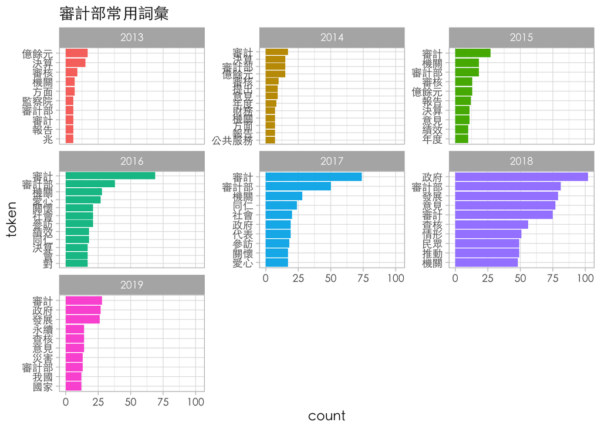

```r
data_clean %>%
        group_by(year) %>%
        count(token) %>%
        top_n(10, wt = n) %>%
        ungroup() %>%
        ggplot(aes(x = tidytext::reorder_within(x = token, by = n,
                                                within = year),
                   y = n, fill = factor(year))) +
        geom_col(show.legend = FALSE) +
        tidytext::scale_x_reordered() +
        facet_wrap(~ year, scales = "free_y") +
        coord_flip() +
        labs(x = "token", y = "count", title = "審計部常用詞彙")
```

```r
# 將製作好的圖另存成png檔
ggsave(filename = "HW4_nao_plot.png", dpi = "retina", width = 15, height = 10)
```

## 6. 從畫出的圖來看，簡單說明一下你認為審計部歷年來的新聞發布重點有哪些？有什麼樣的轉變？（不用寫在code chunk中）

（以下內容為同學提供）

一、「審計」、「審計部」、「審核」、「查核」等詞彙使用次數最為頻繁

縱觀審計部在2013至2019這7年來的新聞發布資訊，「審計」、「審計部」、「審核」、「查核」等詞彙的使用次數，大多名列前茅，主要原因可能與審計部涉及之相關業務內容有關。根據最高審計機關組織(INTOSAI)的定義，審計業務可分為財務報表審計、合規性審計、績效審計等3類，審計部在宣導審計業務時，經常會使用這3項詞彙；而審計部的審計成果多以審核意見、審計意見、查核意見、審核通知、審核報告、查核報告的形式表達，因此，「審計」、「審核」、「查核」等詞彙使用次數較多，並不意外。另外，審計部在發布重要審計成果時，標題及內文均以「審計部」作為主詞，因此使用次數也相對較多。

二、常用詞彙使用次數排名變化

2.「愛心」、「關懷」、「參訪」在2016及2017年使用次數進入前10名 尤其是2016年更名列第四名至第六名，主要原因可能為從2016年開始，審計部開始增加參訪、捐助社會福利機構，而審計部佳音合唱團至老人安養院義演的次數也較為頻繁，因此該等詞彙使用次數較多。

4.「永續」、「災害」等在2019年開始進入前10名的名單 審計部在2019年1月加入永續發展目標聯盟，加上聯合國在2015年通過2030年永續發展議程，公布17項永續發展目標後，審計部開始著重各機關呼應永續發展目標情形的查核，因此「永續」、「災害」開始出現在前10名，不過目前只到2019年4月，整年度使用詞彙排名仍待後續觀察。